# Workshop Week 1

Author

Affiliation

STAT5003

School of Mathematics and Statistics

# Learning Outcomes

**Important**

1. **Data Structures**: Create and manipulate data frames, factors, vectors, and matrices in R.
2. **File I/O**: Read from and write to CSV files in R.
3. **Numerical Summaries**: Use `summary()` to get basic statistics.
4. **Graphical Summaries**: Create plots to visualize data.
5. **Data Manipulation**: Filter and subset data, saving specific subsets.

**These skills are essential for data handling and analysing data in your group projects.**

## Truth or Bluff?

**Objective**: This group activity will help you get to know your classmates by sharing fun and interesting facts.

1. **Preparation**: You write down two true statements and one false statement about yourself.
2. **Grouping**: Form small groups with the people sitting around you.
3. **Sharing**: Within your small groups, take turns sharing three statements.
4. **Guessing**: Group members guess which statement is the lie.
5. **Reveal**: The student reveals which statement was the bluff.

## Data structure

Before you start, *create a new RStudio project* in a new directory. Then, start your workshop by writing your answers in a new *R Markdown file*.

## File I/O

**Read**

1. Download the `Cereal.csv` file from the Canvas page and use the `read.csv` command to read in the csv file into `R` and assign it to the object called `cereal`.

```r
library(readr)
library(dplyr)
library(ggplot2)
library(here) # The `here` package simplifies the process of constructing file paths in R projects.

cereal <- read.csv(here("workshops/datasets", "Cereal.csv"))
cereal |> glimpse() # The `glimpse()` function from the `dplyr` package provides a quick overview of the `cereal` dataset.
```

```
Rows: 77
Columns: 16
$ name     <chr> "100%_Bran", "100%_Natural_Bran", "All-Bran", "All-Bran_with_…
$ mfr      <chr> "N", "Q", "K", "K", "R", "G", "K", "G", "R", "P", "Q", "G", "…
$ type     <chr> "C", "C", "C", "C", "C", "C", "C", "C", "C", "C", "C", "C", "…
$ calories <int> 70, 120, 70, 50, 110, 110, 110, 130, 90, 90, 120, 110, 120, 1…
$ protein  <int> 4, 3, 4, 4, 2, 2, 2, 3, 2, 3, 1, 6, 1, 3, 1, 2, 2, 1, 1, 3, 3…
$ fat      <int> 1, 5, 1, 0, 2, 2, 0, 2, 1, 0, 2, 2, 3, 2, 1, 0, 0, 0, 1, 3, 0…
$ sodium   <int> 130, 15, 260, 140, 200, 180, 125, 210, 200, 210, 220, 290, 21…
$ fiber    <dbl> 10.0, 2.0, 9.0, 14.0, 1.0, 1.5, 1.0, 2.0, 4.0, 5.0, 0.0, 2.0,…
$ carbo    <dbl> 5.0, 8.0, 7.0, 8.0, 14.0, 10.5, 11.0, 18.0, 15.0, 13.0, 12.0,…
$ sugars   <int> 6, 8, 5, 0, 8, 10, 14, 8, 6, 5, 12, 1, 9, 7, 13, 3, 2, 12, 13…
$ potass   <int> 280, 135, 320, 330, -1, 70, 30, 100, 125, 190, 35, 105, 45, 1…
$ vitamins <int> 25, 0, 25, 25, 25, 25, 25, 25, 25, 25, 25, 25, 25, 25, 25, 25…
$ shelf    <int> 3, 3, 3, 3, 3, 1, 2, 3, 1, 3, 2, 1, 2, 3, 2, 1, 1, 2, 2, 3, 2…
$ weight   <dbl> 1.00, 1.00, 1.00, 1.00, 1.00, 1.00, 1.00, 1.33, 1.00, 1.00, 1…
$ cups     <dbl> 0.33, 1.00, 0.33, 0.50, 0.75, 0.75, 1.00, 0.75, 0.67, 0.67, 0…
$ rating   <dbl> 68.40297, 33.98368, 59.42551, 93.70491, 34.38484, 29.50954, 3…
```

**Data frames**

1. Use `head(cereal)` to view the first few lines and `class(cereal)` to confirm it’s a data frame.

```r
# using pipe
cereal|>  head(7)
```

```
                       name mfr type calories protein fat sodium fiber carbo
1                 100%_Bran   N    C       70       4   1    130  10.0   5.0
2         100%_Natural_Bran   Q    C      120       3   5     15   2.0   8.0
3                  All-Bran   K    C       70       4   1    260   9.0   7.0
4 All-Bran_with_Extra_Fiber   K    C       50       4   0    140  14.0   8.0
5            Almond_Delight   R    C      110       2   2    200   1.0  14.0
6   Apple_Cinnamon_Cheerios   G    C      110       2   2    180   1.5  10.5
7               Apple_Jacks   K    C      110       2   0    125   1.0  11.0
  sugars potass vitamins shelf weight cups   rating
1      6    280       25     3      1 0.33 68.40297
2      8    135        0     3      1 1.00 33.98368
3      5    320       25     3      1 0.33 59.42551
4      0    330       25     3      1 0.50 93.70491
5      8     -1       25     3      1 0.75 34.38484
6     10     70       25     1      1 0.75 29.50954
7     14     30       25     2      1 1.00 33.17409
```

```r
cereal |> class() # tells us this is a dataframe
```

```
[1] "data.frame"
```

2. Use `colnames(cereal)` for column names and `dim(cereal)` or `nrow(cereal)` for the number of rows.

```r
cereal |> colnames()
```

```
 [1] "name"     "mfr"      "type"     "calories" "protein"  "fat"
 [7] "sodium"   "fiber"    "carbo"    "sugars"   "potass"   "vitamins"
[13] "shelf"    "weight"   "cups"     "rating"
```

```r
cereal |> nrow()
```

```
[1] 77
```

```r
cereal |> dim()
```

```
[1] 77 16
```

3. Extract the `calories` column

```r
# Extracts the 'calories' column from the 'cereal' data frame and assigns it to 'Cal' as a vector.
Cal <- cereal$calories

# Selects the 'calories' column from the 'cereal' data frame and assigns it to 'Cal' as a data frame.
Cal <- cereal |> select(calories)

# Pulls the 'calories' column from the 'cereal' data frame and assigns it to 'Cal' as a vector.
Cal <- cereal |> pull(calories)
```

4. Extract rows 1 to 10 from the `cereal` data frame.

```r
# Extracts the first 10 rows from the 'cereal' data frame using base R.
cereal[1:10,]
```

```
                        name mfr type calories protein fat sodium fiber carbo
1                  100%_Bran   N    C       70       4   1    130  10.0   5.0
2          100%_Natural_Bran   Q    C      120       3   5     15   2.0   8.0
3                   All-Bran   K    C       70       4   1    260   9.0   7.0
4  All-Bran_with_Extra_Fiber   K    C       50       4   0    140  14.0   8.0
5             Almond_Delight   R    C      110       2   2    200   1.0  14.0
6    Apple_Cinnamon_Cheerios   G    C      110       2   2    180   1.5  10.5
7                Apple_Jacks   K    C      110       2   0    125   1.0  11.0
8                    Basic_4   G    C      130       3   2    210   2.0  18.0
9                  Bran_Chex   R    C       90       2   1    200   4.0  15.0
10               Bran_Flakes   P    C       90       3   0    210   5.0  13.0
   sugars potass vitamins shelf weight cups   rating
1       6    280       25     3   1.00 0.33 68.40297
2       8    135        0     3   1.00 1.00 33.98368
3       5    320       25     3   1.00 0.33 59.42551
4       0    330       25     3   1.00 0.50 93.70491
5       8     -1       25     3   1.00 0.75 34.38484
6      10     70       25     1   1.00 0.75 29.50954
7      14     30       25     2   1.00 1.00 33.17409
8       8    100       25     3   1.33 0.75 37.03856
9       6    125       25     1   1.00 0.67 49.12025
10      5    190       25     3   1.00 0.67 53.31381
```

```r
# Extracts the first 10 rows from the 'cereal' data frame using the tidyverse approach.
cereal |> slice(1:10)
```

```
                        name mfr type calories protein fat sodium fiber carbo
1                  100%_Bran   N    C       70       4   1    130  10.0   5.0
2          100%_Natural_Bran   Q    C      120       3   5     15   2.0   8.0
3                   All-Bran   K    C       70       4   1    260   9.0   7.0
4  All-Bran_with_Extra_Fiber   K    C       50       4   0    140  14.0   8.0
5             Almond_Delight   R    C      110       2   2    200   1.0  14.0
6    Apple_Cinnamon_Cheerios   G    C      110       2   2    180   1.5  10.5
7                Apple_Jacks   K    C      110       2   0    125   1.0  11.0
8                    Basic_4   G    C      130       3   2    210   2.0  18.0
9                  Bran_Chex   R    C       90       2   1    200   4.0  15.0
10               Bran_Flakes   P    C       90       3   0    210   5.0  13.0
   sugars potass vitamins shelf weight cups   rating
1       6    280       25     3   1.00 0.33 68.40297
2       8    135        0     3   1.00 1.00 33.98368
3       5    320       25     3   1.00 0.33 59.42551
4       0    330       25     3   1.00 0.50 93.70491
5       8     -1       25     3   1.00 0.75 34.38484
6      10     70       25     1   1.00 0.75 29.50954
7      14     30       25     2   1.00 1.00 33.17409
8       8    100       25     3   1.33 0.75 37.03856
9       6    125       25     1   1.00 0.67 49.12025
10      5    190       25     3   1.00 0.67 53.31381
```

5. Filter the cereal data frame to include only rows where `mfr` is `"K"` and assign it to `Kelloggs`.

```r
Kelloggs <- cereal |> filter(mfr == "K")
```

**Factors**

1. Load the `Cereal` data again with the `read.csv` command again. This time, use the optional argument, `stringsAsFactors = TRUE`. The `mfr` and `type` columns are now factors. Check that this is true.

```r
# converting character columns to factors.
cereal.with.factors <- read.csv(here("workshops/datasets","Cereal.csv"), stringsAsFactors = TRUE)
cereal.with.factors
```

```
                                     name mfr type calories protein fat sodium
1                               100%_Bran   N    C       70       4   1    130
2                       100%_Natural_Bran   Q    C      120       3   5     15
3                                All-Bran   K    C       70       4   1    260
4               All-Bran_with_Extra_Fiber   K    C       50       4   0    140
5                          Almond_Delight   R    C      110       2   2    200
6                 Apple_Cinnamon_Cheerios   G    C      110       2   2    180
7                             Apple_Jacks   K    C      110       2   0    125
8                                 Basic_4   G    C      130       3   2    210
9                               Bran_Chex   R    C       90       2   1    200
10                            Bran_Flakes   P    C       90       3   0    210
11                           Cap'n'Crunch   Q    C      120       1   2    220
12                               Cheerios   G    C      110       6   2    290
13                  Cinnamon_Toast_Crunch   G    C      120       1   3    210
14                               Clusters   G    C      110       3   2    140
```

[output cut: 141 more lines]

```r
# Shows the structure of 'cereal.with.factors', indicating that only character columns are converted to factors.
str(cereal.with.factors) # only characters become factors
```

```
'data.frame':   77 obs. of  16 variables:
 $ name    : Factor w/ 77 levels "100%_Bran","100%_Natural_Bran",..: 1 2 3 4 5 6 7 8 9 10 ...
 $ mfr     : Factor w/ 7 levels "A","G","K","N",..: 4 6 3 3 7 2 3 2 7 5 ...
 $ type    : Factor w/ 2 levels "C","H": 1 1 1 1 1 1 1 1 1 1 ...
 $ calories: int  70 120 70 50 110 110 110 130 90 90 ...
 $ protein : int  4 3 4 4 2 2 2 3 2 3 ...
 $ fat     : int  1 5 1 0 2 2 0 2 1 0 ...
 $ sodium  : int  130 15 260 140 200 180 125 210 200 210 ...
 $ fiber   : num  10 2 9 14 1 1.5 1 2 4 5 ...
 $ carbo   : num  5 8 7 8 14 10.5 11 18 15 13 ...
 $ sugars  : int  6 8 5 0 8 10 14 8 6 5 ...
 $ potass  : int  280 135 320 330 -1 70 30 100 125 190 ...
 $ vitamins: int  25 0 25 25 25 25 25 25 25 25 ...
 $ shelf   : int  3 3 3 3 3 1 2 3 1 3 ...
 $ weight  : num  1 1 1 1 1 1 1 1.33 1 1 ...
 $ cups    : num  0.33 1 0.33 0.5 0.75 0.75 1 0.75 0.67 0.67 ...
 $ rating  : num  68.4 34 59.4 93.7 34.4 ...
```

```r
# Shows the structure of the original 'cereal' data frame.
str(cereal)
```

```
'data.frame':   77 obs. of  16 variables:
 $ name    : chr  "100%_Bran" "100%_Natural_Bran" "All-Bran" "All-Bran_with_Extra_Fiber" ...
 $ mfr     : chr  "N" "Q" "K" "K" ...
 $ type    : chr  "C" "C" "C" "C" ...
 $ calories: int  70 120 70 50 110 110 110 130 90 90 ...
 $ protein : int  4 3 4 4 2 2 2 3 2 3 ...
 $ fat     : int  1 5 1 0 2 2 0 2 1 0 ...
 $ sodium  : int  130 15 260 140 200 180 125 210 200 210 ...
 $ fiber   : num  10 2 9 14 1 1.5 1 2 4 5 ...
 $ carbo   : num  5 8 7 8 14 10.5 11 18 15 13 ...
 $ sugars  : int  6 8 5 0 8 10 14 8 6 5 ...
 $ potass  : int  280 135 320 330 -1 70 30 100 125 190 ...
 $ vitamins: int  25 0 25 25 25 25 25 25 25 25 ...
 $ shelf   : int  3 3 3 3 3 1 2 3 1 3 ...
 $ weight  : num  1 1 1 1 1 1 1 1.33 1 1 ...
 $ cups    : num  0.33 1 0.33 0.5 0.75 0.75 1 0.75 0.67 0.67 ...
 $ rating  : num  68.4 34 59.4 93.7 34.4 ...
```

2. How many levels are there in `mfr` and `type`? (use the functions `levels` or `nlevels`) - levels will only count FACTORS not CHARACTER strings

```r
levels(cereal.with.factors$mfr)
```

```
[1] "A" "G" "K" "N" "P" "Q" "R"
```

```r
## or
nlevels(cereal.with.factors$mfr)
```

```
[1] 7
```

```r
## or
str(cereal.with.factors$mfr)
```

```
 Factor w/ 7 levels "A","G","K","N",..: 4 6 3 3 7 2 3 2 7 5 ...
```

**Vectors**

1. Extract the `calories` into a new vector called `cereal.calories`.

```r
# Select the 'calories' column from the 'cereal' data frame and convert it to a vector.
cereal.calories <- cereal |> select(calories) |> pull()
```

2. How many elements are there in `cereal.calories`? (`length`)

```r
# length(cereal.calories) - old way
cereal.calories |> length()
```

```
[1] 77
```

3. Extract the 5th to the 10th element from `cereal.calories`.

```r
cereal.calories[5:10]
```

```
[1] 110 110 110 130  90  90
```

4. Add one more element to `cereal.calories` using `c()`.

```r
# Add the value 1.0 to the end of the 'cereal.calories' vector using the concatenate function 'c'.
cereal.calories <- c(cereal.calories, 1.0) # c for concatenate

# Get the length of the 'cereal.calories' vector to see how many elements it contains.
length(cereal.calories)
```

```
[1] 78
```

**Matrix**

1. Can you force the cereal data frame to be a Matrix? (`as.matrix(cereal)`). Check that the elements have been forced into the character type.

```r
# Convert the 'cereal' data frame to a matrix.
cereal.matrix <- as.matrix(cereal)

# Check if 'cereal.matrix' is indeed a matrix.
is.matrix(cereal.matrix)
```

```
[1] TRUE
```

2. Now do this again, but this time leave out the `mfr`, `name` and `type` columns. Check that the elements are now numeric.

```r
# Remove the 'mfr', 'name', and 'type' columns from the 'cereal' data frame.
cereal.removed <- cereal |> select(-c(mfr, name, type))

# Display the column names of the modified 'cereal.removed' data frame.
cereal.removed |> colnames()
```

```
 [1] "calories" "protein"  "fat"      "sodium"   "fiber"    "carbo"
 [7] "sugars"   "potass"   "vitamins" "shelf"    "weight"   "cups"
[13] "rating"
```

```r
# Convert the 'cereal.removed' data frame to a numeric matrix.
cereal.numeric.matrix <- as.matrix(cereal.removed)

# Display the structure of the 'cereal.numeric.matrix'.
str(cereal.numeric.matrix)
```

```
 num [1:77, 1:13] 70 120 70 50 110 110 110 130 90 90 ...
 - attr(*, "dimnames")=List of 2
  ..$ : NULL
  ..$ : chr [1:13] "calories" "protein" "fat" "sodium" ...
```

## Numerical summary

**Summary**

1. Use the `summary` function to extract the median, 1st quartile and 3rd quartile data from the `sodium` column.

```r
summary(cereal$sodium)
```

```
   Min. 1st Qu.  Median    Mean 3rd Qu.    Max.
    0.0   130.0   180.0   159.7   210.0   320.0
```

**Basic statistics**

```r
cereal |>  pull(sodium)|> summary()
```

```
   Min. 1st Qu.  Median    Mean 3rd Qu.    Max.
    0.0   130.0   180.0   159.7   210.0   320.0
```

3. Find the mean `sodium` of each `mfr`.

```r
# Calculate the mean sodium content for each manufacturer ('mfr') in the 'cereal' data frame using the aggregate function.
mean.sodiums <- aggregate(sodium ~ mfr, data = cereal, FUN = mean)

# Display the resulting data frame with mean sodium values for each manufacturer.
mean.sodiums
```

```
  mfr   sodium
1   A   0.0000
2   G 200.4545
3   K 174.7826
4   N  37.5000
5   P 146.1111
6   Q  92.5000
7   R 198.1250
```

```r
# Alternatively, select the 'sodium' and 'mfr' columns from the 'cereal' data frame, group by 'mfr', and calculate the mean sodium content for each group using the tidyverse approach.
cereal |>
    select(sodium, mfr) |>
    group_by(mfr) |>
    summarise(mean_sodium = mean(sodium))
```

```
# A tibble: 7 × 2
  mfr   mean_sodium
  <chr>       <dbl>
1 A             0
2 G           200.
3 K           175.
4 N            37.5
5 P           146.
6 Q            92.5
7 R           198.
```

## Graphical summary

**Boxplot**

1. Make a boxplot of the `sodium` against `mfr` using `boxplot()`.

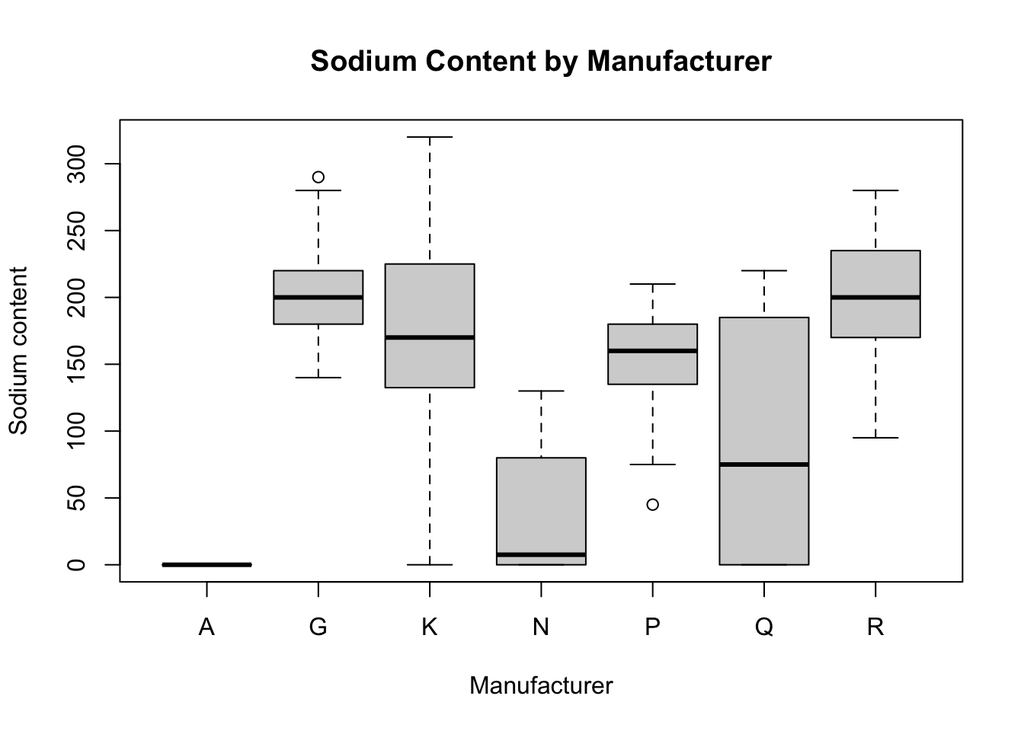

```r
# Create a boxplot of sodium content by manufacturer using base R.
# labels for both axes and give a meaningful title
boxplot(sodium ~ mfr, data = cereal,
        xlab = "Manufacturer", ylab = "Sodium content", main = "Sodium Content by Manufacturer")
```

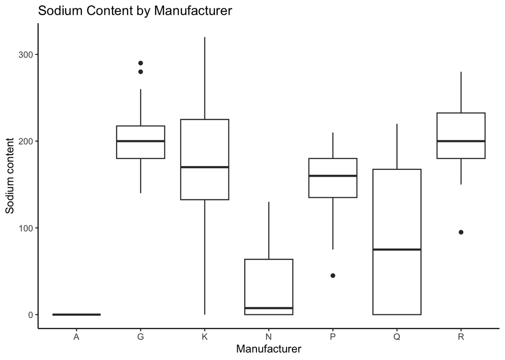

```r
# Using ggplot2.

cereal |>
  ggplot(aes(x = mfr, y = sodium)) +
  geom_boxplot() +
  theme_classic() +
  labs(x =  "Manufacturer", y = "Sodium content") +
  ggtitle("Sodium Content by Manufacturer")
```

**Scatter plot**

2. Plot `calories` against `sodium` using `plot()`.

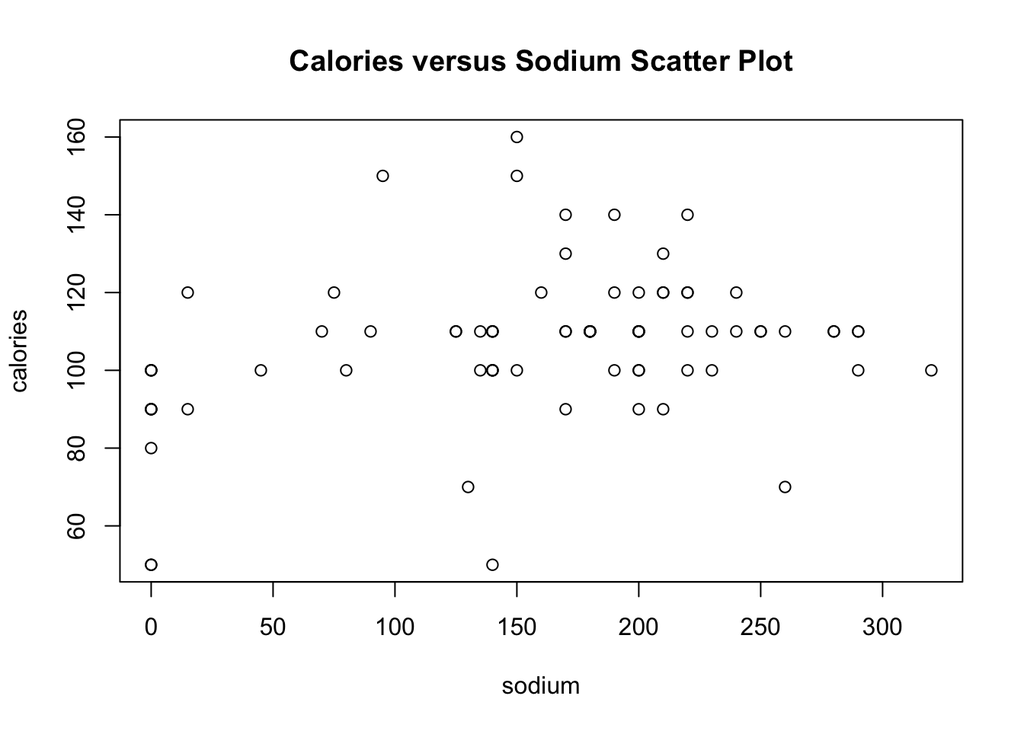

```r
# Create a scatter plot of calories versus sodium using base R.
# The plot has the title "Calories versus Sodium Scatter Plot".
plot(calories ~ sodium, data = cereal, main = "Calories versus Sodium Scatter Plot")
```

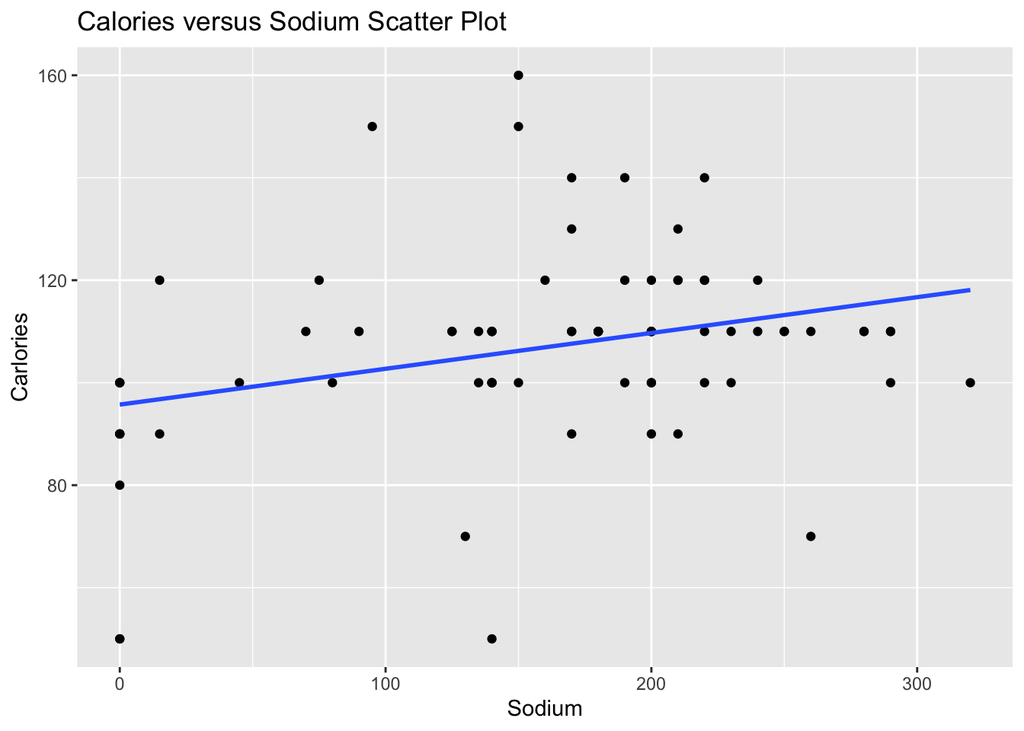

```r
# Create a scatter plot of calories versus sodium using ggplot2.
# Add a linear regression line without the confidence interval.
# The plot has the title "Calories versus Sodium Scatter Plot".
cereal |>
  ggplot(aes(x = sodium, y = calories)) +
  geom_point() +
  geom_smooth(method = "lm", se = FALSE) +
  labs(x =  "Sodium", y = "Carlories") +
  ggtitle("Calories versus Sodium Scatter Plot")
```

## Write Data to File

2. Write data frame with only the Kellogg’s observations to a file called `kelloggs.csv`. Use the `write.csv` command.

```r
write.csv(Kelloggs, here("workshops/datasets", "kelloggs.csv"))
```